# Aula 10 - Introdução à Econometria

Autor

João Ricardo F. de Lima

Data de Publicação

10 de novembro de 2025

# Quebra de Pressupostos do Modelo Clássico de Regressão Linear

# Autocorrelação e viés de especificação

## O que é Autocorrelação?

Pode existir autocorrelação no cross-section, mas é muito mais presente em séries temporais. Existe dependência entre os termos de erro $(E(u_i u_j \ne 0 \quad \forall \quad i \ne j))$. Diversos fatores podem gerar a correlação serial, como por exemplo:

1. inércia;
2. viés de especificação;
3. ausência de estacionariedade;

Com relação à propriedade dos estimadores, com autocorrelação, os estimadores de MQO são não-viesados e consistentes, mas não são eficientes. **Os testes t e F não são mais válidos**.

Nesta situação, da mesma forma que para a heterocedasticidade, é melhor utilizar o método de Mínimos Quadrados Generalizados (MQG).

Considere um modelo com resíduos que tem correlação de primeira ordem:

$$u_t=\rho u_{t-1}+v_t$$
em que $\rho$ é o parâmetro de autocorrelação e “v” é um termo de erro “bem comportado”, ou seja, não autocorrelacionado que segue a distribuição Normal com média zero e variância constante $\sigma^2$.

O coeficiente de autocorrelação $\rho$ pode ser obtido através de

$$\hat \rho = \frac {cov(\epsilon_t, \epsilon_{t-1})}{[var(\epsilon_t)^{1/2}] [var(\epsilon_{t-1})^{1/2}]}$$

Com base nesta idéia, alguns testes foram desenvolvidos visando verificar a presença de autocorrelação nos resíduos da regressão.

## Autocorrelação: Como Detectar?

Considere o modelo abaixo, uma série temporal que se inicia em 1947 e faz uma regressão do consumo em função da renda, da riqueza e da taxa de juros. As três primeiras variáveis estão em log.

```r
library(reticulate)
use_condaenv("py-econo", require = TRUE)
py_config()
```

```
python:         C:/Users/Lenovo/AppData/Local/r-miniconda/envs/py-econo/python.exe
libpython:      C:/Users/Lenovo/AppData/Local/r-miniconda/envs/py-econo/python311.dll
pythonhome:     C:/Users/Lenovo/AppData/Local/r-miniconda/envs/py-econo
version:        3.11.14 | packaged by conda-forge | (main, Oct 22 2025, 22:35:28) [MSC v.1944 64 bit (AMD64)]
Architecture:   64bit
numpy:          C:/Users/Lenovo/AppData/Local/r-miniconda/envs/py-econo/Lib/site-packages/numpy
numpy_version:  2.3.4

NOTE: Python version was forced by use_python() function
```

```r
#Direcionado o R para o Diretorio a ser trabalhado
setwd('C:/Users/Lenovo/Dropbox/tempecon/facape')

#Inicio do Script

#Pacotes a serem usados
library(forecast)
library(ggplot2)
#library(easyGgplot2)
library(urca)
library(stargazer)
library(tseries)
library(lmtest)
library(car)
library(sandwich)
#install.packages('scatterplot3d')
library(scatterplot3d)

options(digits=4)

#Extracao dos dados
dados <- read.csv2('autocorrelacao.csv', header=T, sep=";", dec=".")
dados <- ts(dados, start=c(1947))

#Estimacao da Equacao de Regressao
regressao1 <- lm(log(consumo) ~log(renda) + log(riqueza) + tx_juros, data=dados)
summary(regressao1)
```

```
Call:
lm(formula = log(consumo) ~ log(renda) + log(riqueza) + tx_juros,
    data = dados)

Residuals:
     Min       1Q   Median       3Q      Max
-0.01844 -0.01000  0.00034  0.00704  0.03258

Coefficients:
              Estimate Std. Error t value Pr(>|t|)
(Intercept)  -0.467711   0.042778  -10.93  7.3e-15 ***
log(renda)    0.804873   0.017498   46.00  < 2e-16 ***
log(riqueza)  0.201270   0.017593   11.44  1.4e-15 ***
tx_juros     -0.002689   0.000762   -3.53    9e-04 ***
---
Signif. codes:  0 '***' 0.001 '**' 0.01 '*' 0.05 '.' 0.1 ' ' 1

Residual standard error: 0.0119 on 50 degrees of freedom
Multiple R-squared:     1,  Adjusted R-squared:     1
F-statistic: 3.78e+04 on 3 and 50 DF,  p-value: <2e-16
```

### MÉTODO GRÁFICO

Apesar de existirem testes estatísticos, uma análise gráfica pode ser útil para tentar verificar algum comportamento nos dados que de indicativo se existência de autocorrelação.

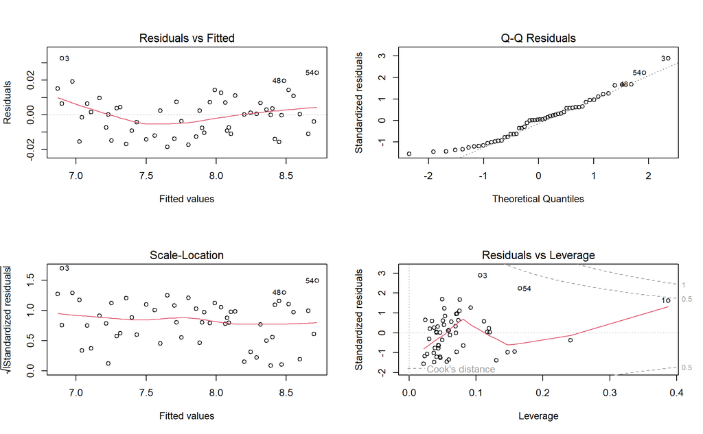

```r
#Analise dos residuos do modelo
par(mfrow=c(2,2))
plot(regressao1)
```

```r
resid <- regressao1$residuals
resid <- ts(resid, start=c(1947))
```

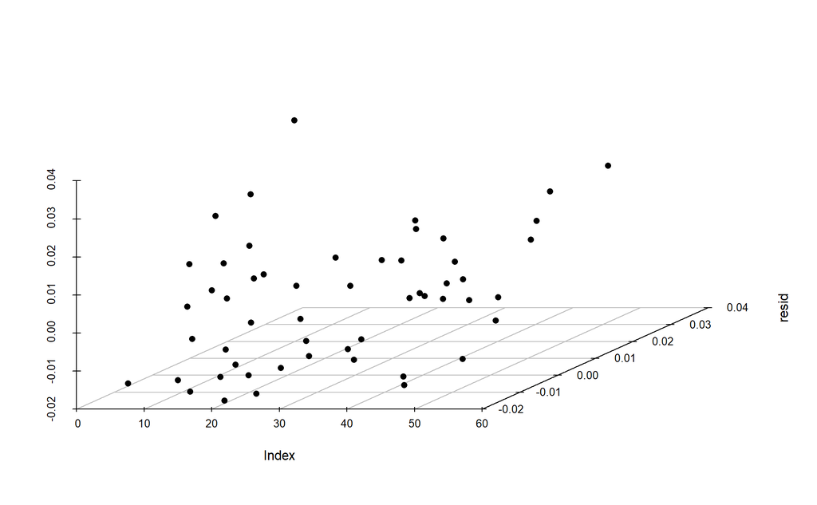

```r
par(mfrow=c(1,1))
scatterplot3d(lag(resid,-1), resid, pch=16, box=FALSE)
```

### TESTE DE DURBIN-WATSON

O teste mais conhecido é o “d” de Durbin-Watson (razão da soma das diferenças ao quadrado entre os sucessivos resíduos e a soma de quadrados dos resíduos):

$$d=\frac{\sum_{t=2}^{t=n}(\hat{u}_t-\hat{u}_{t-1})^2}{\sum_{t=1}^{t=n}(\hat{u}_t^2)}$$

Possui importantes premissas:

1. a regressão precisa ter intercepto;
2. o termo de erro precisa ser um AR(1) ($u_t=\rho u_{t-1}+v_t$), não pode ser AR de ordem superior;
3. o erro deve ser normal;
4. o modelo não pode ter termos defasados da variável dependente (y);

Não há um único valor crítico que leve a rejeição ou não da hipótese nula (ausência de autocorrelação), contudo o R mostra um valor de Probabilidade. Gujarati e Porter (2009) demonstram facilmente que $d\approx2(1- \hat{\rho})$.

$$\hat{u}_t=\hat{\rho} u_{t-1}+v_t$$

Dado que $-1\le \rho \le 1$, tem-se que $0\le d \le 4$, que são os limites de “d”. Como regra prática, espera-se que d esteja próximo de 2 para pressupor que não existe autocorrelação nos resíduos. Quanto mais próximo de 0 (zero), maior a evidência de auto positiva e de 4, de auto negativa.

```r
#Teste de Durbin-Watson
# Testa the hipotese que nao existe correlacao de 1 lag nos residuos
dwtest(regressao1, alt="two.sided")
```

```
    Durbin-Watson test

data:  regressao1
DW = 1.3, p-value = 0.002
alternative hypothesis: true autocorrelation is not 0
```

### TESTE DE BREUSCH-GODFREY

Teste que permite regressandos defasados inclusos como regressores, processos autoregressivos (AR) de ordens maiores do que 1 e Termos de médias móveis (MA).

Suponha que o termo de erro siga a seguinte estrutura:

$$u_t=\rho_1u_{t-1}+\rho_2u_{t-2}+\dots+\rho_pu_{t-p}+v_t$$

$v_t$ é um erro que segue as hipóteses do MCRL.

A hipótese nula do teste BG é

$$H_0=\rho_1=\rho_2=\dots=\rho_p=0$$

**Ausência de autocorrelação de qualquer ordem**. Dada a não observação de $u_t$ é usado a sua estimativa e estimada uma regressão auxiliar de $e_t$ contra as variáveis explicativas e os termos de erros defasados. Em grandes amostras, o teste BG segue a distribuição $(n-p)R^2 \sim \chi_p^2$.

O teste BG possui as seguintes características:

1. A variância de $u_t$ seja homocedástica;
2. Definir a ordem de “p”. Normalmente isto é um processo de tentativa e erro, com o uso de critérios de Akaike ou Schwarz para definição do melhor modelo. Deve ser escolhido o modelo com menor valor de critério de informação;

```r
#Teste de Breusch-Godfrey
#AIC(regressao1)
#BIC(regressao1)
bg1 <- bgtest(regressao1,1)
coeftest(bg1)
```

```
z test of coefficients:

              Estimate Std. Error z value Pr(>|z|)
(Intercept)   0.000739   0.041033    0.02    0.986
log(renda)   -0.000259   0.016784   -0.02    0.988
log(riqueza)  0.000131   0.016875    0.01    0.994
tx_juros      0.000181   0.000735    0.25    0.806
lag(resid)_1  0.330377   0.142885    2.31    0.021 *
---
Signif. codes:  0 '***' 0.001 '**' 0.01 '*' 0.05 '.' 0.1 ' ' 1
```

```r
bg1
```

```
    Breusch-Godfrey test for serial correlation of order up to 1

data:  regressao1
LM test = 5.3, df = 1, p-value = 0.02
```

```r
bg2 <- bgtest(regressao1,2)
coeftest(bg2)
```

```
z test of coefficients:

              Estimate Std. Error z value Pr(>|z|)
(Intercept)  -0.006514   0.041528   -0.16    0.875
log(renda)   -0.004197   0.017158   -0.24    0.807
log(riqueza)  0.004191   0.017271    0.24    0.808
tx_juros      0.000116   0.000736    0.16    0.875
lag(resid)_1  0.385190   0.151581    2.54    0.011 *
lag(resid)_2 -0.165610   0.154695   -1.07    0.284
---
Signif. codes:  0 '***' 0.001 '**' 0.01 '*' 0.05 '.' 0.1 ' ' 1
```

```r
bg2
```

```
    Breusch-Godfrey test for serial correlation of order up to 2

data:  regressao1
LM test = 6.4, df = 2, p-value = 0.04
```

```r
bg3 <- bgtest(regressao1,3)
coeftest(bg3)
```

```
z test of coefficients:

              Estimate Std. Error z value Pr(>|z|)
(Intercept)  -4.62e-03   4.21e-02   -0.11    0.912
log(renda)   -2.46e-03   1.77e-02   -0.14    0.889
log(riqueza)  2.55e-03   1.78e-02    0.14    0.886
tx_juros      8.88e-05   7.45e-04    0.12    0.905
lag(resid)_1  3.92e-01   1.54e-01    2.55    0.011 *
lag(resid)_2 -1.90e-01   1.65e-01   -1.15    0.249
lag(resid)_3  7.23e-02   1.58e-01    0.46    0.648
---
Signif. codes:  0 '***' 0.001 '**' 0.01 '*' 0.05 '.' 0.1 ' ' 1
```

```r
bg3
```

```
    Breusch-Godfrey test for serial correlation of order up to 3

data:  regressao1
LM test = 6.7, df = 3, p-value = 0.08
```

## Autocorrelação: Como Corrigir?

Existem diversas formas de corrigir a autocorrelação:

1. Transformar as séries, diferenciando-as, caso se saiba o valor de $\rho$ ou considerando $\rho=1$;
2. Fazer uma transformação generalizada: $Y_t- \hat{\rho}(Y_{t-1})$ para obter $\hat{\rho}$, fazer $\approx 1-\frac{d}{2}$;
3. Usar o método de correção dos erros padrões de Newey-West (HAC-Consistente com auto e hetero), desde que a amostra seja grande. Erros robustos.

Com base em Figueiro (2021), o cálculo dos erros-padrão por estimativas robustas serão desejáveis para formas mais gerais de correlação serial, diga-se, com autocorrelações de ordens superiores.

Desta forma, estima-se o modelo padrão de regressão linear por MQO. Em seguida, se pega os resíduos estimados de uma regressão auxiliar de $x_{1t}$ em função dos demais $x_{kt}$ e calcula-se $\hat a = \hat r_t \hat u_t$ em que $\hat u_t$ são os resíduos da estimação original por MQO. Por uma escolha de “g”, que pode variar entre a parte inteira de $4(n/100)^{2/9}$ ou $n^{1/4}$, calcula-se

$$\hat v= \sum_{t=1}^{n} k^2 \hat a^2_t + 2 \sum_{h=1}^{g} [1-h/(g+1)]\Big(\sum_{t=h+1}^{n} \hat a_t \hat a{t-h}\Big)$$

e $ep(\hat \beta_1)=[SE/\hat \sigma]^2\sqrt(\hat v)$, em que SE é o erro padrão usual do MQO para $\hat \beta_j$.

Desta forma obtêm-se os erros-padrões robustos dos parâmetros. Fazendo uso do pacote `sandwich`, e a opção para a matriz de variância-covariância consistente com heterocedasticidade e autocorrelação `vcov=NeweyWest` conforme o script abaixo. Conforme a ordem da autocorelação (se acima da primeira ordem), pode ser mais indicado considerar o tratamento para a estrutura geral de Newey e West (1987) e Wooldridge (1989), citados por Wooldridge (2016, seção 12.5).

```r
#Correcao do problema da Autocorrelacao - Duas formas

regressao1 <- lm(log(consumo) ~log(renda) + log(riqueza) + tx_juros, data=dados)
coeftest(regressao1, vcov=NeweyWest)
```

```
t test of coefficients:

             Estimate Std. Error t value Pr(>|t|)
(Intercept)  -0.46771    0.04440  -10.53  2.7e-14 ***
log(renda)    0.80487    0.01621   49.64  < 2e-16 ***
log(riqueza)  0.20127    0.01452   13.86  < 2e-16 ***
tx_juros     -0.00269    0.00082   -3.28   0.0019 **
---
Signif. codes:  0 '***' 0.001 '**' 0.01 '*' 0.05 '.' 0.1 ' ' 1
```

## Exemplo no Python

```python
#Direcionado o R para o Diretorio a ser trabalhado
import os
import pandas as pd
import numpy as np
import matplotlib.pyplot as plt
import seaborn as sns
import statsmodels.formula.api as smf
import statsmodels.stats.stattools as sms
from statsmodels.tsa.stattools import adfuller
import statsmodels.stats.diagnostic as diag
from statsmodels.stats.diagnostic import acorr_breusch_godfrey

os.chdir('C:/Users/Lenovo/Dropbox/tempecon/facape')

#Inicio do Script

df = pd.read_csv(filepath_or_buffer = "autocorrelacao.csv", header=0, sep =';', decimal = ".")
df.head()
```

```
   consumo   renda   riqueza   tx_juros
0    976.4  1035.2  5166.815 -10.350940
1    998.1  1090.0  5280.757  -4.719804
2   1025.3  1095.6  5607.351   1.044063
3   1090.9  1192.7  5759.515   0.407346
4   1107.1  1227.0  6086.056  -5.283152
```

```python
# Create a date range starting from 1947 with yearly frequency
date_range = pd.date_range(start='1947', periods=len(df), freq='YE')

# Set the date range as the index of the DataFrame
df.index = date_range

# Display the first few rows of the DataFrame to verify the index
print(df.head())
```

```
            consumo   renda   riqueza   tx_juros
1947-12-31    976.4  1035.2  5166.815 -10.350940
1948-12-31    998.1  1090.0  5280.757  -4.719804
1949-12-31   1025.3  1095.6  5607.351   1.044063
1950-12-31   1090.9  1192.7  5759.515   0.407346
1951-12-31   1107.1  1227.0  6086.056  -5.283152
```

```python
#Estimacao da Equacao de Regressao
reg1 = smf.ols('np.log(consumo) ~ np.log(renda) + np.log(riqueza) + tx_juros', data=df)

#Output do Resultado
result1 = reg1.fit()
print(result1.summary())
```

```
                            OLS Regression Results
==============================================================================
Dep. Variable:        np.log(consumo)   R-squared:                       1.000
Model:                            OLS   Adj. R-squared:                  1.000
Method:                 Least Squares   F-statistic:                 3.783e+04
Date:                seg, 10 nov 2025   Prob (F-statistic):           7.12e-84
Time:                        14:48:38   Log-Likelihood:                 164.59
No. Observations:                  54   AIC:                            -321.2
Df Residuals:                      50   BIC:                            -313.2
Df Model:                           3
Covariance Type:            nonrobust
===================================================================================
                      coef    std err          t      P>|t|      [0.025      0.975]
-----------------------------------------------------------------------------------
Intercept          -0.4677      0.043    -10.933      0.000      -0.554      -0.382
np.log(renda)       0.8049      0.017     45.998      0.000       0.770       0.840
np.log(riqueza)     0.2013      0.018     11.441      0.000       0.166       0.237
tx_juros           -0.0027      0.001     -3.529      0.001      -0.004      -0.001
==============================================================================
Omnibus:                        1.995   Durbin-Watson:                   1.289
Prob(Omnibus):                  0.369   Jarque-Bera (JB):                1.806
Skew:                           0.438   Prob(JB):                        0.405
Kurtosis:                       2.811   Cond. No.                         357.
==============================================================================

Notes:
[1] Standard Errors assume that the covariance matrix of the errors is correctly specified.
```

```python
# Check for autocorrelation using the Durbin-Watson statistic
dw_statistic = sms.durbin_watson(result1.resid)
print('Durbin-Watson:', dw_statistic)
```

```
Durbin-Watson: 1.2892186018849905
```

```python
import statsmodels.api as sm
import pandas as pd

resid = result1.resid
df_resid = pd.DataFrame({'u': resid})

max_lags = 10
rows = []

for lags in range(1, max_lags + 1):
    lm_stat, lm_pvalue, f_stat, f_pvalue = acorr_breusch_godfrey(result1, nlags=lags)
    rows.append({
        'Lags': lags,
        'LM-stat': lm_stat,
        'LM p-value': lm_pvalue,
        'F-stat': f_stat,
        'F p-value': f_pvalue
    })

results_bg = pd.DataFrame(rows)


print(results_bg)
```

```
   Lags    LM-stat  LM p-value    F-stat  F p-value
0     1   5.312169    0.021177  5.346228   0.025011
1     2   6.447585    0.039804  3.254136   0.047282
2     3   6.657660    0.083648  2.203172   0.100118
3     4   6.735779    0.150527  1.638903   0.180627
4     5   7.404112    0.192278  1.430105   0.231886
5     6   8.824691    0.183680  1.432517   0.223991
6     7   9.271746    0.233730  1.273356   0.286118
7     8  10.560532    0.227864  1.276323   0.281632
8     9  10.666883    0.299235  1.121396   0.370013
9    10  12.362958    0.261499  1.187688   0.327692
```

```python
resid = result1.resid
df_resid = pd.DataFrame({'u': resid})

max_lag = 10
aic_list = []
bic_list = []

for p in range(1, max_lag + 1):
    df_aux = df_resid.copy()

    # cria as defasagens dos resíduos
    for j in range(1, p + 1):
        df_aux[f'u_lag{j}'] = df_aux['u'].shift(j)

    df_aux = df_aux.dropna()

    y = df_aux['u']
    X = df_aux[[f'u_lag{j}' for j in range(1, p + 1)]]
    X = sm.add_constant(X)

    model_p = sm.OLS(y, X).fit()

    aic_list.append(model_p.aic)
    bic_list.append(model_p.bic)

    print(f"p = {p} | AIC = {model_p.aic:.4f} | BIC = {model_p.bic:.4f}")
```

```
p = 1 | AIC = -325.4201 | BIC = -321.4795
p = 2 | AIC = -317.4751 | BIC = -311.6213
p = 3 | AIC = -319.5923 | BIC = -311.8650
p = 4 | AIC = -311.1256 | BIC = -301.5655
p = 5 | AIC = -304.3552 | BIC = -293.0043
p = 6 | AIC = -297.3955 | BIC = -284.2971
p = 7 | AIC = -288.3071 | BIC = -273.5059
p = 8 | AIC = -281.1464 | BIC = -264.6887
p = 9 | AIC = -272.7242 | BIC = -254.6576
p = 10 | AIC = -268.8646 | BIC = -249.2385
```

Há evidência de autocorrelação de $1^a$ e de $2^a$ ordem nos resíduos do modelo. A partir do 3 lag não se rejeita mais a hipótese nula. um processo AR(1) já captura bem a estrutura da autocorrelação dos resíduos, se for considerado o critério de informação.

## Correlação da autocorrelação no Python

```python
result_hac1 = result1.get_robustcov_results(
    cov_type='HAC',
    maxlags=1  # número de defasagens na correção Newey-West
)

print(result_hac1.summary())
```

```
                            OLS Regression Results
==============================================================================
Dep. Variable:        np.log(consumo)   R-squared:                       1.000
Model:                            OLS   Adj. R-squared:                  1.000
Method:                 Least Squares   F-statistic:                 2.433e+04
Date:                seg, 10 nov 2025   Prob (F-statistic):           4.40e-79
Time:                        14:48:38   Log-Likelihood:                 164.59
No. Observations:                  54   AIC:                            -321.2
Df Residuals:                      50   BIC:                            -313.2
Df Model:                           3
Covariance Type:                  HAC
===================================================================================
                      coef    std err          t      P>|t|      [0.025      0.975]
-----------------------------------------------------------------------------------
Intercept          -0.4677      0.049     -9.547      0.000      -0.566      -0.369
np.log(renda)       0.8049      0.018     45.367      0.000       0.769       0.841
np.log(riqueza)     0.2013      0.017     11.761      0.000       0.167       0.236
tx_juros           -0.0027      0.001     -2.979      0.004      -0.005      -0.001
==============================================================================
Omnibus:                        1.995   Durbin-Watson:                   1.289
Prob(Omnibus):                  0.369   Jarque-Bera (JB):                1.806
Skew:                           0.438   Prob(JB):                        0.405
Kurtosis:                       2.811   Cond. No.                         357.
==============================================================================

Notes:
[1] Standard Errors are heteroscedasticity and autocorrelation robust (HAC) using 1 lags and without small sample correction
```

Mantém o modelo original, mas usa-se erros-padrão robustos Newey-West para corrigir o efeito da autocorrelação. Esta é uma solução prática e muito usada na literatura aplicada.

# Viés de Especificação

**Omitir uma variável relevante** - *Conseqüências*:

1. se a variável omitida for correlacionada com alguma incluída, os betas estimados são tendenciosos e inconsistentes;
2. se não existir correlação, o intercepto é viesado;
3. a variância do erro estará errada;
4. IC, erros padrão e testes de hipóteses não são calculados corretamente.

**Inserir uma variável irrelevante** - *Conseqüências*: a perda da eficiência, ou seja, erros-padrão maiores do que as dos parâmetros do modelo verdadeiro.

A conclusão é que incluir uma variável irrelevante é menos problemático do que omitir uma variável relevante. Existem alguns testes para identificar problemas na especificação dos modelos.

## Viés de Especificação: como detectar?

O Teste Reset de Ramsey é usado para analisar má especificação do modelo. É um teste mais geral, tanto de variáveis irrelevantes, quanto de forma funcional incorreta e correlação entre os regressores e o termo de erro. A hipótese nula é de que o modelo inicialmente estimado está bem especificado. Uma falha no teste é que diz que o modelo não está bem especificado, mas não se sabe qual alternativa é a melhor. Deve-se testar outras formas, com outras variáveis e ir refazendo o teste.

Considere um modelo de regressão

$$y=\beta_0+\beta_1x_1+ \dots +\beta_kx_k+u$$

se a hipótese $E(u|x_1,x_2, \dots ,x_k)=0$ for violada isto indica que a relação funcional entre as variáveis explicadas e explicativas está mal especificada, como mostra Wooldridge (2018, p. 90).

O Teste Reset adiciona polinômios aos valores estimados por MQO na equação acima para verificar se são significativos e detectar tipos gerais de má especificação de formas funcionais.

Para fazer o teste é preciso definir quantas funções dos valores estimados serão incluídos na regressão expandida. No geral, quadráticos e cúbicos tem dado bons resultados.

A estatistica do teste é dada por

$$F= \frac{\frac{R^2_{novo}-R^2_{velho}}{m}}{\frac{1-R^2_{novo}}{n-p}}$$

em que m é o número de novos regressores e p é o número de parâmetros no novo modelo.

$F \sim F_{m,n-p}$ com n igual ao número de observações.

## Viés de Especificação: exemplo no R.

```r
#Direcionado o R para o Diretorio a ser trabalhado
#setwd('/Users/jricardofl/Dropbox/tempecon/facape/econometria2')

#Limpa o Ambiente Global
rm(list=ls())

#Inicio do Script
#Analise de Regressao com o R
#Pacotes a serem utilizados
library(foreign)
library(lmtest)
library(wooldridge)

data("wage2")
dados <- na.omit(wage2)

attach(dados)

#Regressao Multipla

regressao1 <- lm(lwage ~ educ + I(educ^2) + tenure)
summary(regressao1)
```

```
Call:
lm(formula = lwage ~ educ + I(educ^2) + tenure)

Residuals:
    Min      1Q  Median      3Q     Max
-1.9091 -0.2470  0.0223  0.2552  1.2845

Coefficients:
            Estimate Std. Error t value Pr(>|t|)
(Intercept)  4.80703    0.66271    7.25  1.1e-12 ***
educ         0.21609    0.09488    2.28    0.023 *
I(educ^2)   -0.00548    0.00334   -1.64    0.101
tenure       0.01445    0.00296    4.88  1.3e-06 ***
---
Signif. codes:  0 '***' 0.001 '**' 0.01 '*' 0.05 '.' 0.1 ' ' 1

Residual standard error: 0.384 on 659 degrees of freedom
Multiple R-squared:  0.137, Adjusted R-squared:  0.133
F-statistic: 34.9 on 3 and 659 DF,  p-value: <2e-16
```

```r
#Teste de especificação do Modelos
#Hipotese Nula: Modelo esta bem especificado.
resettest(regressao1, power=2 , type='fitted')
```

```
    RESET test

data:  regressao1
RESET = 0.12, df1 = 1, df2 = 658, p-value = 0.7
```

```r
resettest(regressao1, power=3 , type='fitted')
```

```
    RESET test

data:  regressao1
RESET = 0.0086, df1 = 1, df2 = 658, p-value = 0.9
```

```r
#Estimacao do Modelo Linear
regressao2 <- lm(lwage ~ educ + exper + tenure)
summary(regressao2)
```

```
Call:
lm(formula = lwage ~ educ + exper + tenure)

Residuals:
    Min      1Q  Median      3Q     Max
-1.8574 -0.2360  0.0171  0.2460  1.3081

Coefficients:
            Estimate Std. Error t value Pr(>|t|)
(Intercept)  5.50223    0.12825   42.90  < 2e-16 ***
educ         0.07572    0.00745   10.17  < 2e-16 ***
exper        0.01799    0.00408    4.41  1.2e-05 ***
tenure       0.00986    0.00307    3.22   0.0014 **
---
Signif. codes:  0 '***' 0.001 '**' 0.01 '*' 0.05 '.' 0.1 ' ' 1

Residual standard error: 0.379 on 659 degrees of freedom
Multiple R-squared:  0.159, Adjusted R-squared:  0.155
F-statistic: 41.4 on 3 and 659 DF,  p-value: <2e-16
```

```r
#Teste de especificacao do Modelos
#Hipotese Nula: Modelo esta bem especificado.
resettest(regressao2, power=2 , type='fitted')
```

```
    RESET test

data:  regressao2
RESET = 0.1, df1 = 1, df2 = 658, p-value = 0.7
```

```r
resettest(regressao2, power=3 , type='fitted')
```

```
    RESET test

data:  regressao2
RESET = 0.95, df1 = 1, df2 = 658, p-value = 0.3
```

O teste Reset de Ramsey é usado para analisar má especificação do modelo. É um teste mais geral, tanto de variáveis irrelevantes, quanto de forma funcional incorreta e correlação entre os regressores e o termo de erro.

## Viés de Especificação: exemplo no Python.

```python
#Direcionado o R para o Diretorio a ser trabalhado
#setwd('/Users/jricardofl/Dropbox/tempecon/facape/econometria2')

import wooldridge
import pandas as pd
import numpy as np
import matplotlib.pyplot as plt
import seaborn as sns
import statsmodels.formula.api as smf
import scipy.stats as stats
from statsmodels.stats.diagnostic import linear_reset

#Carregar dados no computador
wage2 = wooldridge.data('wage2')

wage2 = wage2.dropna()

#Estimando a 1 Regressão Multipla Modelo Irrestrito
reg1 = smf.ols('np.log(wage) ~ educ + I(educ**2) + tenure', data=wage2)
#Output de Resultado
result1 = reg1.fit()
print(result1.summary())
```

```
                            OLS Regression Results
==============================================================================
Dep. Variable:           np.log(wage)   R-squared:                       0.137
Model:                            OLS   Adj. R-squared:                  0.133
Method:                 Least Squares   F-statistic:                     34.93
Date:                seg, 10 nov 2025   Prob (F-statistic):           5.85e-21
Time:                        14:48:39   Log-Likelihood:                -303.77
No. Observations:                 663   AIC:                             615.5
Df Residuals:                     659   BIC:                             633.5
Df Model:                           3
Covariance Type:            nonrobust
================================================================================
                   coef    std err          t      P>|t|      [0.025      0.975]
--------------------------------------------------------------------------------
Intercept        4.8070      0.663      7.254      0.000       3.506       6.108
educ             0.2161      0.095      2.277      0.023       0.030       0.402
I(educ ** 2)    -0.0055      0.003     -1.644      0.101      -0.012       0.001
tenure           0.0145      0.003      4.881      0.000       0.009       0.020
==============================================================================
Omnibus:                       18.530   Durbin-Watson:                   1.864
Prob(Omnibus):                  0.000   Jarque-Bera (JB):               29.961
Skew:                          -0.212   Prob(JB):                     3.12e-07
Kurtosis:                       3.951   Cond. No.                     9.11e+03
==============================================================================

Notes:
[1] Standard Errors assume that the covariance matrix of the errors is correctly specified.
[2] The condition number is large, 9.11e+03. This might indicate that there are
strong multicollinearity or other numerical problems.
```

```python
# Ramsey's RESET test
reset_test = linear_reset(result1, power=2, use_f=True)
print("RESET test p-value:", reset_test.pvalue)
```

```
RESET test p-value: 0.728135293582924
```

```python
# Ramsey's RESET test
reset_test = linear_reset(result1, power=3, use_f=True)
print("RESET test p-value:", reset_test.pvalue)
```

```
RESET test p-value: 0.9261338172954598
```

```python
#Estimando a 1 Regressão Multipla Modelo restrito
reg2 = smf.ols('np.log(wage) ~ educ + exper + tenure', data=wage2)
#Output de Resultado
result2 = reg2.fit()
print(result2.summary())
```

```
                            OLS Regression Results
==============================================================================
Dep. Variable:           np.log(wage)   R-squared:                       0.159
Model:                            OLS   Adj. R-squared:                  0.155
Method:                 Least Squares   F-statistic:                     41.39
Date:                seg, 10 nov 2025   Prob (F-statistic):           1.63e-24
Time:                        14:48:39   Log-Likelihood:                -295.46
No. Observations:                 663   AIC:                             598.9
Df Residuals:                     659   BIC:                             616.9
Df Model:                           3
Covariance Type:            nonrobust
==============================================================================
                 coef    std err          t      P>|t|      [0.025      0.975]
------------------------------------------------------------------------------
Intercept      5.5022      0.128     42.902      0.000       5.250       5.754
educ           0.0757      0.007     10.167      0.000       0.061       0.090
exper          0.0180      0.004      4.415      0.000       0.010       0.026
tenure         0.0099      0.003      3.217      0.001       0.004       0.016
==============================================================================
Omnibus:                       16.700   Durbin-Watson:                   1.850
Prob(Omnibus):                  0.000   Jarque-Bera (JB):               27.658
Skew:                          -0.175   Prob(JB):                     9.86e-07
Kurtosis:                       3.937   Cond. No.                         171.
==============================================================================

Notes:
[1] Standard Errors assume that the covariance matrix of the errors is correctly specified.
```

```python
# Ramsey's RESET test
reset_test = linear_reset(result2, power=2, use_f=True)
print("RESET test p-value:", reset_test.pvalue)
```

```
RESET test p-value: 0.7462249802442938
```

```python
# Ramsey's RESET test
reset_test = linear_reset(result2, power=3, use_f=True)
print("RESET test p-value:", reset_test.pvalue)
```

```
RESET test p-value: 0.5602710671404385
```